[Portfolio Home](https://jmerchen.github.io/Jackson_Merchen.github.io/)

# Sampling Distributions Unveiled

This document explores sampling to discover true regression lines.

True Regression:

$Y_i = 100 - 3 * X_i + \epsilon_i$ where $\epsilon$ ~ $N(0, \sigma^2)$

## Sampling Distribution

The true regression line is rarely ever known, like it is in this situation. Finding a single sample from the population can help us find estimates for the y-intercept and slope of the regression, but a single sample could give us values such as the sample below, where the intercept was estimated nearly 22 points below the true intercept and the slope was half a point away from the true slope. This was despite having a sample of 100 data points.

```r
set.seed(200)
X1 = rnorm(100, 50, 5)
error1 <- rnorm(100, 0, 11)
Y1 = 100 - 3*X1 + error1
lm1 <- lm(Y1 ~ X1)
summary(lm1) %>%
  pander()
```

|  | Estimate | Std. Error | t value | Pr(>\|t\|) |
| --- | --- | --- | --- | --- |
| **(Intercept)** | 78.79 | 10.14 | 7.772 | 7.768e-12 |
| **X1** | -2.586 | 0.2014 | -12.84 | 1.003e-22 |

Fitting linear model: Y1 ~ X1

| Observations | Residual Std. Error | $R^2$ | Adjusted $R^2$ |
| --- | --- | --- | --- |
| 100 | 9.214 | 0.6273 | 0.6235 |

Our estimate of the true regression can be enhanced by taking many samples. When many samples are taken from the population to find a statistic, this is called a sampling distribution. Taking just 100 samples from our population gives us the distributions modeled below.

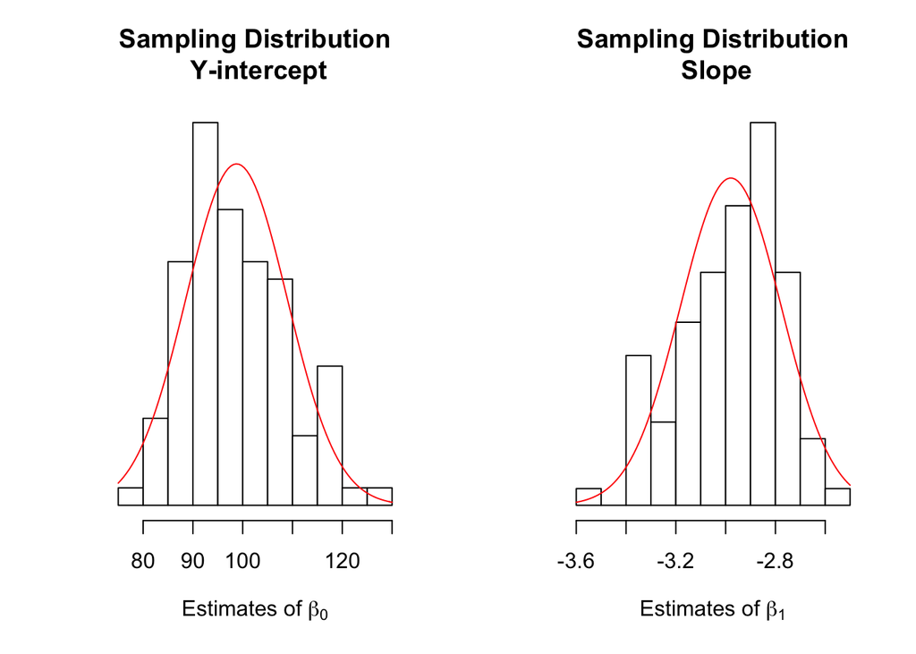

```r
set.seed(9876)
X <- rnorm(100, 50, 5)
Call <- 100
b0 <- rep(NA, Call)
b1 <- rep(NA, Call)
sig <- rep(NA, Call)

for (i in 1:Call){
  Y <- 100 - 3*X + rnorm(100, 0, 11)
  samp <- lm(Y ~ X)
  b0[i] <- coef(samp)[1]
  b1[i] <- coef(samp)[2]
  sig[i] <- summary(samp)$sigma
}

sd0 <- sd(b0)
sd1 <- sd(b1)
m0 <- mean(b0)
m1 <- mean(b1)

par(mfrow = c(1,2))
h0 <- hist(b0, col = "white", main = "Sampling Distribution\n Y-intercept", xlab = expression(paste("Estimates of ", beta[0])), freq = FALSE, yaxt = 'n', ylab = "")
curve(dnorm(x, mean(b0), sd(b0)), add = T, col = "red")
h1 <- hist(b1, col = "white", main="Sampling Distribution\n Slope", xlab = expression(paste("Estimates of ", beta[1])), freq = FALSE, yaxt =  'n', ylab = "")
curve(dnorm(x, mean(b1), sd(b1)), add = T, col = "red")
```

These distributions, modeled by a histogram overlaid with a bell-curve, too contain our single sample from before, though we can see that the estimates we obtained from a single regression are on the extremes of the bell-curves and are rarely obtained when the population is sampled.

Finding a better estimate of our true slope and y-intercept can be achieved by looking at the apex of our bell-curves. For the y-intercept, the apex is between 90 and 110 (with a true value of 100). For the slope, the apex is between -3.2 and -2.8 (with a true value of -3). We estimate the true values using the mean from the distribution and then test it using the standard deviation.

```r
RTab <- matrix(c(m0, sd0, m1, sd1), ncol=1, byrow=TRUE)
colnames(RTab) <- c('Value From Distribution')
rownames(RTab) <- c("Mean Intercept", "SD Intercept", "Mean Slope", "SD Slope")
RTab <- as.table(RTab)
pander(RTab)
```

|  | Value From Distribution |
| --- | --- |
| **Mean Intercept** | 98.76 |
| **SD Intercept** | 10.16 |
| **Mean Slope** | -2.979 |
| **SD Slope** | 0.2028 |

## P-Values

The standard deviation is used to test our hypothesis of the true mean. To do this, we first obtain a t-statistic using the equation below:
$$t = (b_0-H_i)/(S_{b_0})$$
Where $H_i$ is our hypothesized value and $S_{b_0}=\sqrt{{MSE}/{\sum{(x_i-\bar{x})^2}}}$, or the standard deviation of our sampling distribution.

Using this t-statistic, we can use r to find the p-value for our hypothesis. For our distributions, we could round to 100 for the y-intercept and -3 for the slope and use these for our hypothesis:
$$\left.\begin{array}{ll}
H_0: \beta_1 = -3 \\
H_a: \beta_1 \neq -3
\end{array}
\right\} \ \text{Slope Hypotheses}
\left.\begin{array}{ll}
H_0: \beta_0 = 100 \\
H_a: \beta_0 \neq 100
\end{array}
\right\} \ \text{Intercept Hypotheses}$$
Using these hypothesis and the equation above, we get that the t-statistic for the slope is 1.029 and the t-statistic for the intercept is -1.216. These t-values give us p-values of .3061 and .2268, respectively. This is summarized in the tables below:

```r
t.test(b1, mu = -3) %>%
  pander()
```

One Sample t-test: `b1`

| Test statistic | df | P value | Alternative hypothesis | mean of x |
| --- | --- | --- | --- | --- |
| 1.029 | 99 | 0.3061 | two.sided | -2.979 |

```r
t.test(b0, mu = 100) %>%
  pander()
```

One Sample t-test: `b0`

| Test statistic | df | P value | Alternative hypothesis | mean of x |
| --- | --- | --- | --- | --- |
| -1.216 | 99 | 0.2268 | two.sided | 98.76 |

The p-value represents the probability of obtaining a value given that the null hypothesis is true. If the probability is low, then we reject the null hypothesis. The p-values for our tests are both above .2, which is not significant and we cannot, therefore, reject our null hypothesis. The p-value can be represented by the area under the bell-curves below in white (with the area under the whole curve equaling 1):

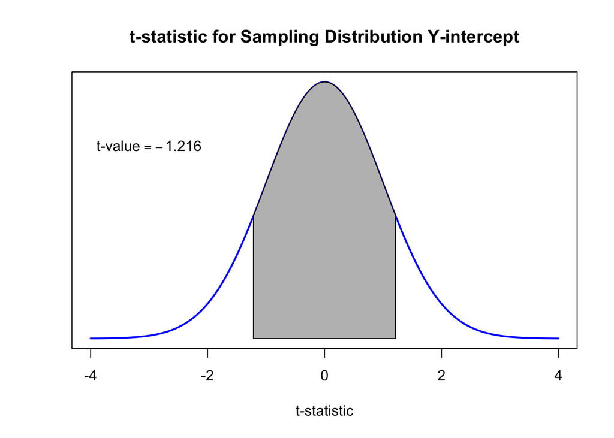

```r
x=seq(-4,4,length=200)
y=dnorm(x)
plot(x,y,type="l", lwd=2, col="blue", yaxt = 'n', ylab = "", xlab = "t-statistic", main = "t-statistic for Sampling Distribution Y-intercept")
x=seq(-1.216,1.216,length=100)
y=dnorm(x)
polygon(c(-1.216, x, 1.216), c(0, y, 0), col = "gray")
text(-3, .3, bquote("t-value" == -1.216))
```

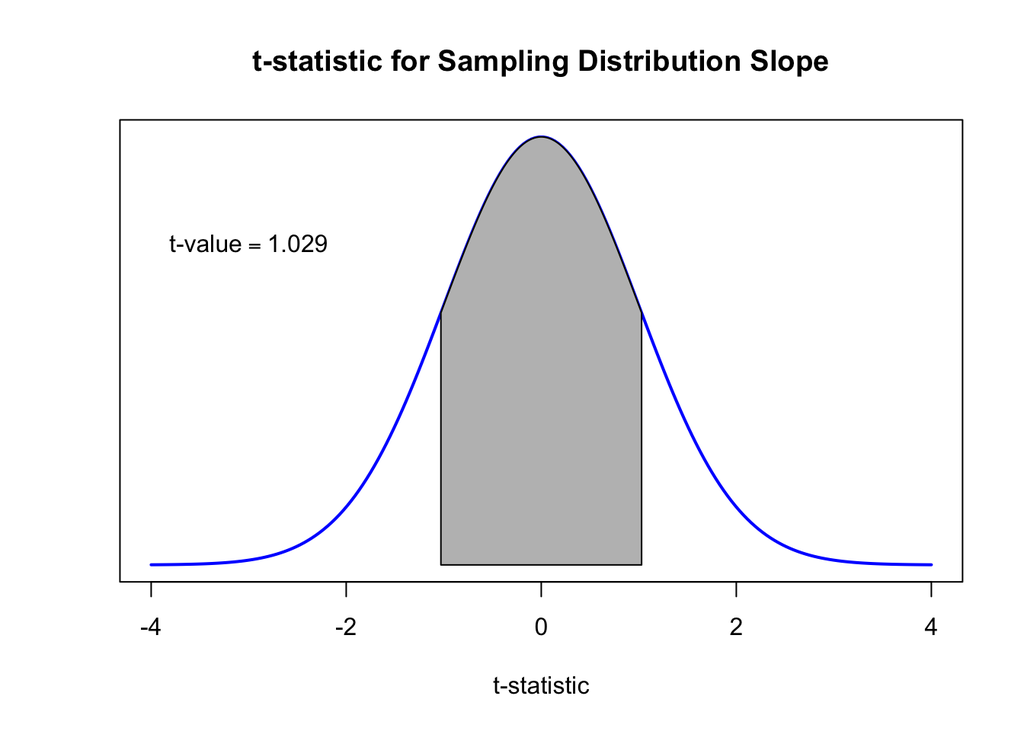

```r
g=seq(-4,4,length=200)
h=dnorm(g)
plot(g,h,type="l", lwd=2, col="blue", yaxt = 'n', ylab = "", xlab = "t-statistic", main = "t-statistic for Sampling Distribution Slope")
g=seq(-1.029,1.029,length=100)
h=dnorm(g)
polygon(c(-1.029, g, 1.029), c(0, h, 0), col = "gray")
text(-3, .3, bquote("t-value" == 1.029))
```

## Confidence Intervals

The equation for a confidence interval is given by the equation below:
$$CI = \bar{x}\pm t_{n-2}*s_{b_0}$$
Using this where $t_{n-2}$ is the t critical value at the chosen confidence level with n-2 degrees of freedom, gives us a confidence interval for our chosen confidence level. A 95% confidence interval tells us that, if we took a sample 100 times and used the equation above, then 95 out of the 100 samples would capture the true value for the population. This tells us that an estimated 95 of our 100 samples captured the true slope and true intercept in their confidence intervals.